# Модель доступа AppArmor

Мандатное управление доступом в Linux

Авраменко Давид Андреевич

1032251973@rudn.ru

Российский университет дружбы народов

2026-10-24

# Введение

## Почему AppArmor актуален

Уязвимость в приложении может привести к злоупотреблению его полномочиями.

Стандартные права файловой системы не всегда ограничивают **конкретную программу**.

Важен принцип **минимально необходимых привилегий**.

AppArmor снижает последствия компрометации приложений

## Цель и задачи

**Цель:** изучить механизм разграничения доступа AppArmor.

**Задачи:**

Разобрать отличие DAC и MAC.

Рассмотреть профили и режимы работы.

Показать настройку, контроль и ограничения механизма.

# Принципы AppArmor

## DAC и MAC: два уровня контроля

**DAC — дискреционный доступ**

Права владельца, группы и остальных.

Разрешения `r`, `w`, `x`.

Контроль зависит от пользователя и файла.

**MAC — мандатный доступ**

Отдельная политика безопасности.

Ограничения действий приложения.

Разрешение MAC не отменяет проверку DAC.

**Итог:** доступ возможен только при прохождении всех применимых проверок.

## Что описывает профиль

```
profile report-reader /usr/local/bin/report-reader {
    #include <abstractions/base>
    /etc/report-reader/config.ini r,
    /var/lib/report-reader/input/** r,
    /var/log/report-reader/** rw,
    network inet stream,
}
```

## Что описывает профиль

Чтение конфигурации и входных файлов.

Чтение и запись журнала.

Отдельное разрешение сетевых сокетов.

Запрет операций вне разрешённой политики.

## Режимы работы

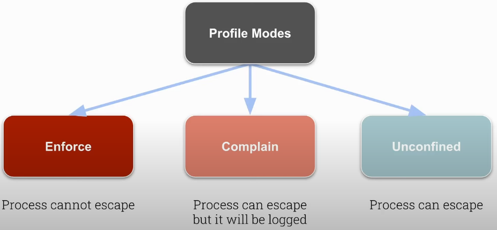

## Режимы работы

`enforce` — реальная защита.

`complain` — отладка и уточнение правил.

`unconfined` — нет действующего ограничивающего профиля.

# Администрирование

## Как создают и проверяют профиль

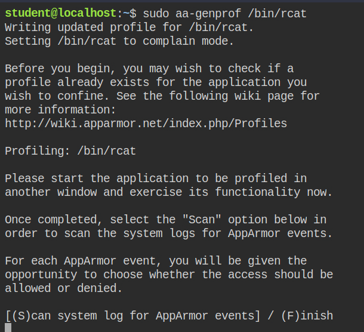

Создание: `aa-genprof`.

Тестирование приложения.

Анализ событий: `aa-logprof`.

Переход в `enforce`.

## Контроль и диагностика

```bash
sudo aa-status
sudo journalctl -k --grep=apparmor
sudo aa-logprof
```

`aa-status` — загруженные профили и режимы.

Журнал ядра — сообщения о запрещённых операциях.

`aa-logprof` — разбор событий и корректировка правил [@apparmor_audit_system].

## AppArmor и SELinux

| Критерий | AppArmor | SELinux |
| --- | --- | --- |
| Основной принцип | Профили приложений и пути | Метки безопасности и политика |
| Администрирование | Текстовые правила по ресурсам | Типы, домены, контексты |
| Особенность | Удобен для адресного ограничения программ | Гибкая модель системной политики |

Оба механизма относятся к MAC и дополняют DAC.

## Преимущества и ограничения

**Преимущества**

Принцип минимальных привилегий.

Читаемые профили.

Режим обучения.

Интеграция с ядром Linux.

**Ограничения**

Защищаются лишь охваченные профилями процессы.

Профили требуют сопровождения.

Изменения путей могут нарушать правила.

Не заменяет обновления, DAC и сетевую защиту.

# Заключение

## Главный вывод

**AppArmor ограничивает полномочия приложений и снижает ущерб при их компрометации.**

Основа — профили MAC и проверки через LSM.

На практике важны режим `enforce` и корректные правила.

Эффективность зависит от полноты охвата процессов.

*AppArmor — дополнительный уровень защиты Linux, а не замена остальных механизмов безопасности.*